# RETAIL DATASET ANALYSIS

Author: CUONG VO  
Student ID: 131116

Technical Information:

- OS: WSL2 Ubuntu 22.04LTS
- Spark: 3.5.0
- Scala: 2.12.18
- Java OpenJDK: 11.0.21

### Library Import

```python
import pandas as pd
import numpy as np
import matplotlib.pyplot as plt
```

### Create Spark Session

```python
from pyspark.sql import SparkSession
from pyspark.sql.types import *
from pyspark.sql.functions import *

spark = SparkSession.builder.appName('Retail Analysis').getOrCreate()
sc = spark.sparkContext
```

### Dataset import

**Source:** https://archive.ics.uci.edu/dataset/352/online+retail

**Abstract:** This dataset captures essential details from online retail transactions, encompassing diverse aspects of the purchase process. This comprehensive dataset allows for the analysis of purchasing patterns, sales trends, and customer behavior across different countries. It provides a valuable resource for exploring various aspects of online retail operations, from product popularity to geographical sales distribution. The inclusion of detailed transaction information enables researchers and analysts to delve into the dynamics of the online retail business and derive insights that can inform strategic decisions.

```python
retail_schema = StructType([
  StructField('InvoiceNo', StringType()),
  StructField('StockCode', StringType()),
  StructField('Description', StringType()),
  StructField('Quantity', IntegerType()),
  StructField('InvoiceDate', StringType()),
  StructField('UnitPrice', FloatType()),
  StructField('CustomerID', StringType()),
  StructField('Country', StringType())
])
```

```python
file_location = "./online_retail.csv"
file_type = "csv"

infer_schema = "true"
first_row_is_header = "true"
delimiter = ","

# The applied options are for CSV files. For other file types, these will be ignored.
df = spark.read.format(file_type) \
  .option("inferSchema", infer_schema) \
  .option("header", first_row_is_header) \
  .option("sep", delimiter) \
  .schema(retail_schema) \
  .load(file_location)

df = df.na.fill("Missing_ID", subset="CustomerID")
df = df.withColumn("Invoice_Date", to_date(substring(df.InvoiceDate, 1,8),"dd-MM-yy"))
df.limit(10).show()
```

```
+---------+---------+--------------------+--------+-------------+---------+----------+--------------+------------+
|InvoiceNo|StockCode|         Description|Quantity|  InvoiceDate|UnitPrice|CustomerID|       Country|Invoice_Date|
+---------+---------+--------------------+--------+-------------+---------+----------+--------------+------------+
|   536365|   85123A|WHITE HANGING HEA...|       6|01-12-10 8:26|     2.55|     17850|United Kingdom|  2010-12-01|
|   536365|    71053| WHITE METAL LANTERN|       6|01-12-10 8:26|     3.39|     17850|United Kingdom|  2010-12-01|
|   536365|   84406B|CREAM CUPID HEART...|       8|01-12-10 8:26|     2.75|     17850|United Kingdom|  2010-12-01|
|   536365|   84029G|KNITTED UNION FLA...|       6|01-12-10 8:26|     3.39|     17850|United Kingdom|  2010-12-01|
|   536365|   84029E|RED WOOLLY HOTTIE...|       6|01-12-10 8:26|     3.39|     17850|United Kingdom|  2010-12-01|
|   536365|    22752|SET 7 BABUSHKA NE...|       2|01-12-10 8:26|     7.65|     17850|United Kingdom|  2010-12-01|
|   536365|    21730|GLASS STAR FROSTE...|       6|01-12-10 8:26|     4.25|     17850|United Kingdom|  2010-12-01|
|   536366|    22633|HAND WARMER UNION...|       6|01-12-10 8:28|     1.85|     17850|United Kingdom|  2010-12-01|
|   536366|    22632|HAND WARMER RED P...|       6|01-12-10 8:28|     1.85|     17850|United Kingdom|  2010-12-01|
|   536367|    84879|ASSORTED COLOUR B...|      32|01-12-10 8:34|     1.69|     13047|United Kingdom|  2010-12-01|
+---------+---------+--------------------+--------+-------------+---------+----------+--------------+------------+
```

After inserting the dataset, a new column named 'Invoice_Date' is created to convert the string date entries into datetime format. The dataset now comprises nine features, and it encompasses over 500,000 instances.

```python
print(df.count(), len(df.columns))
```

```
541909 9
```

We have additionally created a 'Retail_Data' view for Spark SQL commands by utilizing the 'createOrReplaceTempView' method to establish the view.

```python
df.createOrReplaceTempView("Retail_data")
```

```python
df = df.withColumn("Sales", round(df.Quantity * df.UnitPrice,2) )
df_customer = df.groupBy('CustomerID').agg(round(sum("Sales"),2).alias("Total_Sales"))
df_customer.sort("Total_Sales", ascending = [False]).limit(10).show()
```

```
[Stage 4:>                                                        (0 + 11) / 11]
```

```
+----------+-----------+
|CustomerID|Total_Sales|
+----------+-----------+
|Missing_ID| 1447682.12|
|     14646|  279489.02|
|     18102|  256438.49|
|     17450|  187482.17|
|     14911|  132572.62|
|     12415|  123725.45|
|     14156|  113384.14|
|     17511|   88125.38|
|     16684|   65892.08|
|     13694|    62653.1|
+----------+-----------+
```

Similarly, a parallel process was conducted for the product codes, whereby the total sales per product code were summarized.

```python
df_product = df.groupBy('StockCode').agg(
    round(sum("Sales"),2).alias("Total_Sales"))
df_product.sort("Total_Sales", ascending=[False]).limit(10).show()
```

```
[Stage 7:====================================>                     (7 + 4) / 11]
```

```
+---------+-----------+
|StockCode|Total_Sales|
+---------+-----------+
|      DOT|  206245.48|
|    22423|  164762.19|
|    47566|   98302.98|
|   85123A|    97894.5|
|   85099B|   92356.03|
|    23084|   66756.59|
|     POST|   66230.64|
|    22086|   63791.94|
|    84879|   58959.73|
|    79321|   53768.06|
+---------+-----------+
```

### Retail Performance Analysis

#### Timeseries plot

We generated a time series plot depicting the daily revenue, allowing us to visually assess revenue trends over time. This information serves as a foundational element for subsequent time series analysis, enabling the identification of trends and seasonality patterns. Further in-depth analysis of the time series data will be conducted to derive valuable insights

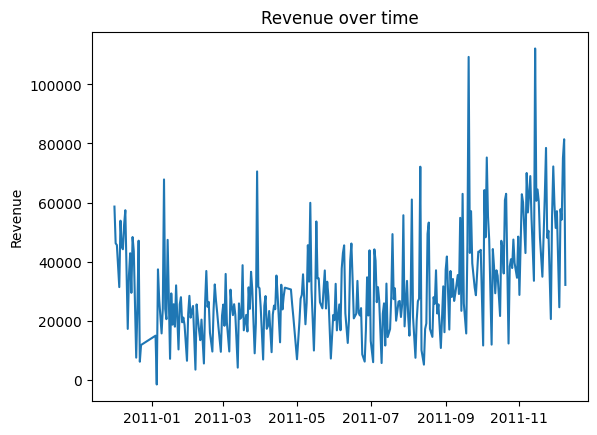

```python
df_ts = spark.sql("""
    Select
        Invoice_Date as ds,
        sum(Quantity * UnitPrice) as y
    From Retail_Data
    group by Invoice_date
    Order by 1
""")

df_ts = df_ts.toPandas()
plt.plot(df_ts["ds"], df_ts["y"])
plt.ylabel("Revenue")
plt.title("Revenue over time")
plt.show()
```

#### Top 10 Client per Sales

We created a visualization highlighting the top 10 clients with the highest revenue, providing a clear understanding of the customers who have made significant expenditures. This insight facilitates targeted promotional strategies, allowing for tailored promotions and marketing initiatives specifically designed to engage and retain this high-value customer segment.

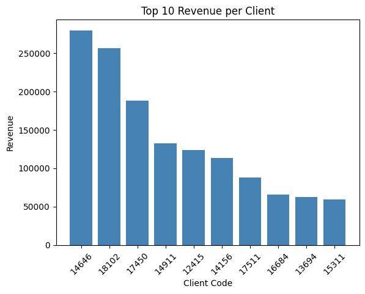

```python
df_Top10_Client = spark.sql("""
    Select
        `CustomerID`,
        sum(Quantity * UnitPrice) as Sales
    From Retail_data
    where `CustomerID` <> 'Missing_ID'
    Group by `CustomerID`
    Order by 2 desc
    """)

df_Top10_Client = df_Top10_Client.limit(10)
df_Top10_Client = df_Top10_Client.toPandas()
plt.bar(df_Top10_Client["CustomerID"], df_Top10_Client["Sales"], color = 'steelblue')
plt.xticks(rotation = 45)
plt.xlabel("Client Code")
plt.ylabel("Revenue")
plt.title("Top 10 Revenue per Client")
plt.show()
```

#### Top 10 Product per Sales

We generated a visualization showcasing the top 10 products based on sales, offering a clear overview of the items with the highest revenue contribution. This chart serves as a valuable resource for management, aiding in strategic planning for inventory management, warehouse optimization, and working capital allocation. By identifying and prioritizing high-performing products, the management can make informed decisions to enhance operational efficiency and profitability.

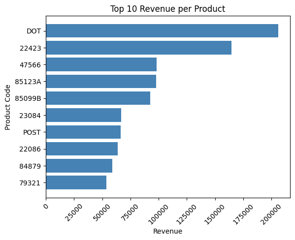

```python
df_Top10_Product = spark.sql("""
    Select
        StockCode,
        sum(Quantity * UnitPrice) as Sales
    From Retail_data
    Group by StockCode
    Order by 2 desc
    """)

df_Top10_Product = df_Top10_Product.limit(10).sort("Sales", ascending = [True])
df_Top10_Product = df_Top10_Product.toPandas()
plt.barh(df_Top10_Product["StockCode"], df_Top10_Product["Sales"], color = 'steelblue')
plt.xticks(rotation = 45)
plt.xlabel("Revenue")
plt.ylabel("Product Code")
plt.title("Top 10 Revenue per Product")
plt.show()
```

#### Top 10 Count per Sales

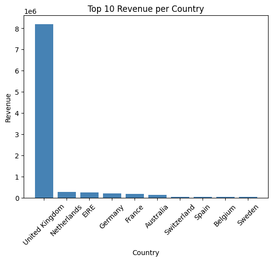

```python
df_Top10_Country = spark.sql("""
    Select
        Country,
        sum(Quantity * UnitPrice) as Sales
    From Retail_data
    Group by Country
    Order by 2 desc
    """)

df_Top10_Country = df_Top10_Country.limit(10)
df_Top10_Country = df_Top10_Country.toPandas()
plt.bar(df_Top10_Country["Country"], df_Top10_Country["Sales"], color = 'steelblue')
plt.xticks(rotation = 45)
plt.xlabel("Country")
plt.ylabel("Revenue")
plt.title("Top 10 Revenue per Country")
plt.show()
```

#### Distibution of Product Price

The histogram provides insights into the distribution of product prices. The majority of unit prices fall within the 0 to 50 USD range, indicative of a range of casual products. However, notable exceptions exist, with a subset of luxury products commanding higher prices, exceeding 100 USD and extending to 200 USD or more. This variation in price points underscores the diverse product offerings within the dataset, catering to both affordable and higher-end markets.  
Understanding the distribution of prices allows us to discern distinct customer segments targeted by the store. The range of product prices, spanning from affordable to luxury items, suggests a strategic approach to catering to diverse customer preferences. This segmentation strategy enables the store to appeal to a broad spectrum of clientele, accommodating both budget-conscious consumers and those seeking higher-end, premium products.

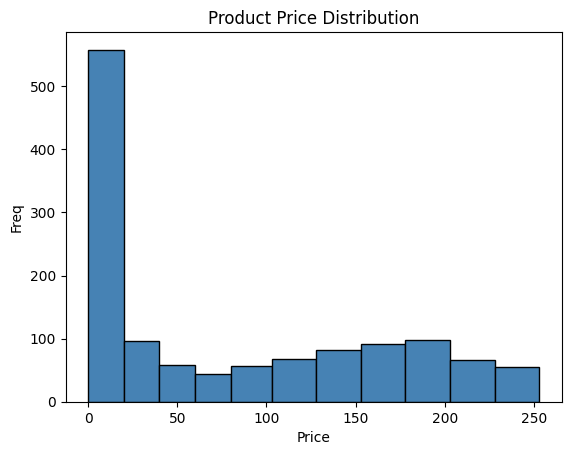

```python
df_price = spark.sql("""
    Select
        UnitPrice
    From Retail_data
    Group by UnitPrice
    """)
df_price = df_price.toPandas()
sum_price = df_price.describe()
bin_gr = []
bin_2 = int(sum_price.loc["50%", "UnitPrice"]/5)
bin_gr = bin_gr + [*range(0, int(sum_price.loc["50%", "UnitPrice"]) - bin_2, bin_2 )]
bin_3 = int((sum_price.loc["75%", "UnitPrice"] - sum_price.loc["50%", "UnitPrice"])/5)
bin_gr = bin_gr + [*range(int(sum_price.loc["50%", "UnitPrice"]), int(sum_price.loc["75%", "UnitPrice"]) + bin_3, bin_3 )]

plt.hist(df_price["UnitPrice"], edgecolor = 'black', bins = bin_gr, color='steelblue')
plt.xlabel("Price")
plt.ylabel("Freq")
plt.title("Product Price Distribution")
plt.show()
```

#### Fast moving and Slow moving Inventory

Two bar charts have been generated to distinguish between fast-moving and slow-moving inventory. This categorization is determined by considering the shopping period and calculating the average number of orders for each product code. These charts offer valuable insights for inventory planning, allowing the management to strategically address both fast-moving and slow-moving inventory. The distinction enables proactive measures, ensuring optimal inventory levels and appropriate strategies for managing slower-moving products in the store's portfolio.

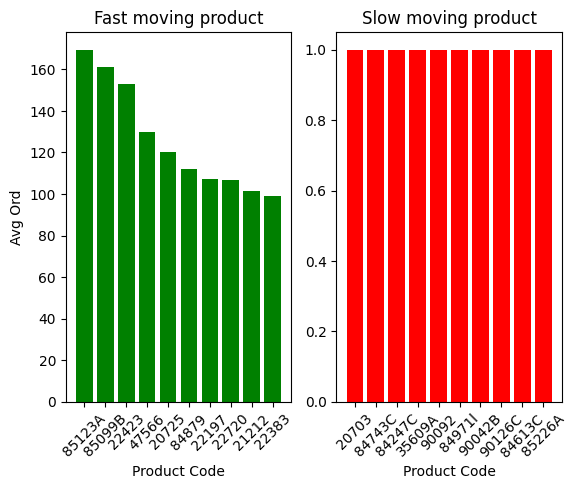

```python
df_moving = spark.sql("""
    Select
        StockCode,
        Count(Date) as No_Month,
        Avg(Ord) as No_Ord
    From
    (
        Select
            StockCode,
            substring(cast(Invoice_Date as String), 1, 7) as Date,
            count(distinct InvoiceNo) as Ord
        From Retail_Data
        where Quantity > 0
        group by StockCode, substring(cast(Invoice_Date as String), 1, 7)
    )
    Group by StockCode
    Order by 2 desc, 3 desc
"""
)

df_moving = df_moving.toPandas()
plt.subplot(1,2,1)
plt.bar(df_moving["StockCode"].head(10), df_moving["No_Ord"].head(10), color = 'green')
plt.xticks(rotation = 45)
plt.xlabel("Product Code")
plt.ylabel("Avg Ord")
plt.title("Fast moving product")
plt.subplot(1,2,2)
plt.bar(df_moving["StockCode"].tail(10), df_moving["No_Ord"].tail(10), color = 'red')
plt.xticks(rotation = 45)
plt.xlabel("Product Code")
plt.title("Slow moving product")
plt.show()
```

#### Return time per client

We computed the average time between two consecutive purchases to determine the return time, enabling the segmentation of customers into distinct groups: loyal and churn clients. This analysis provides insights into customer behavior by identifying those who exhibit regular and frequent purchasing patterns (loyal clients) as opposed to those who demonstrate longer intervals between purchases (churn clients). Such segmentation aids in tailoring targeted strategies for customer retention and engagement.

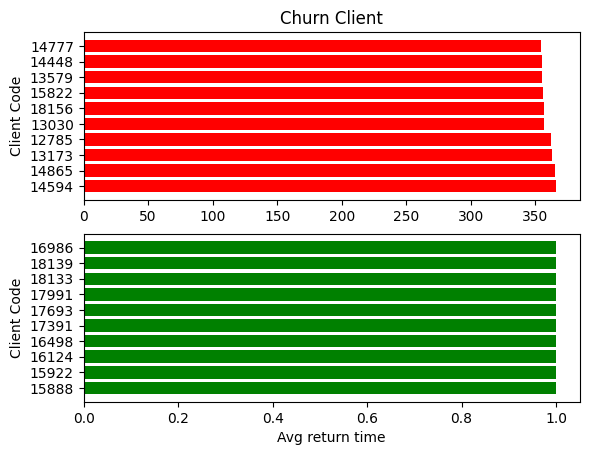

```python
df_return = df.select("CustomerID", "Invoice_Date")
df_return = df_return.dropDuplicates(["CustomerID", "Invoice_Date"])

from pyspark.sql.window import Window

windowSpec = Window.partitionBy("CustomerID").orderBy(desc("Invoice_Date"))

df_return = df_return.withColumn("row_number", row_number().over(windowSpec))
df_return_last = df_return
df_return_last = df_return_last.withColumn("row_number", df_return_last.row_number + 1)
df_return_last = df_return_last.withColumnRenamed("Invoice_Date", "Invoice_Date_last")
df_return = df_return.join(df_return_last, ['CustomerID', 'row_number'])
df_return = df_return.withColumn("gap_time", df_return.Invoice_Date_last - df_return.Invoice_Date)
df_return = df_return.withColumn("gap_time", df_return.gap_time.cast('int'))

df_return = df_return.groupBy("CustomerID").agg(round(avg("gap_time"),2).alias("avg_gap_time"))
df_return = df_return.sort("avg_gap_time", ascending=[False])

df_return = df_return.toPandas()
plt.subplot(2,1,1)
plt.barh(df_return["CustomerID"].head(10), df_return["avg_gap_time"].head(10), color = 'red')
plt.ylabel("Client Code")
plt.title("Churn Client")
plt.subplot(2,1,2)
plt.barh(df_return["CustomerID"].tail(10), df_return["avg_gap_time"].tail(10), color = 'green')
plt.ylabel("Client Code")
plt.xlabel("Avg return time")
plt.show()
```

#### Market Basket Analysis

Market Basket Analysis (MBA) is a well-known analytical tool in the retail grocery domain. Below are few goals that you can achieve with MBA

- Identify frequently purchased items (sell more of such TOP products to increase consumption)
- Upsell and cross-sell products across brands, categories, subcategories and so on. For e.g. if eggs and milk are bought together very frequently, promote only one of them and the other sells automatically

We create the support for each stock code as Spark Dataframe below:

```python
df_prod_freq = df.filter(df.Quantity > 0)
df_prod_freq = df_prod_freq.groupby("StockCode").agg(count("InvoiceNo").alias("count_invoice"))

df_prod_freq = df_prod_freq.crossJoin(
    df_prod_freq.groupby().agg(sum("count_invoice").alias("sum_of_count_invoice"))
)

df_prod_freq = df_prod_freq.withColumn("count_invoice/sum_of_count_invoice", df_prod_freq.count_invoice / df_prod_freq.sum_of_count_invoice)


df_prod_freq.sort("count_invoice/sum_of_count_invoice", ascending = [False]).show(10)
```

```
+---------+-------------+--------------------+----------------------------------+
|StockCode|count_invoice|sum_of_count_invoice|count_invoice/sum_of_count_invoice|
+---------+-------------+--------------------+----------------------------------+
|   85123A|         2270|              531285|              0.004272659683597316|
|   85099B|         2115|              531285|              0.003980914198593975|
|    22423|         2019|              531285|              0.003800220220785454|
|    47566|         1707|              531285|              0.003212964792907761|
|    20725|         1595|              531285|              0.003002155152131154|
|    84879|         1489|              531285|              0.002802638884967...|
|    22197|         1426|              531285|              0.002684058462030...|
|    22720|         1401|              531285|              0.002637002738643101|
|    21212|         1370|              531285|              0.002578653641642433|
|    20727|         1328|              531285|              0.002499600026351205|
+---------+-------------+--------------------+----------------------------------+
only showing top 10 rows
```

We also create the set of stock code for each invoice.

```python
df_agg = df.filter(df.Quantity > 0)
df_agg = df_agg.groupby("InvoiceNo").agg(collect_set("StockCode").alias("Stock_Set"))
df_agg.show(10)
```

```
+---------+--------------------+
|InvoiceNo|           Stock_Set|
+---------+--------------------+
|   536366|      [22632, 22633]|
|   536367|[22310, 22622, 21...|
|   536371|             [22086]|
|   536374|             [21258]|
|   536375|[84029E, 21730, 8...|
|   536385|[22663, 22961, 85...|
|   536386|[85099B, 84880, 8...|
|   536387|[21731, 22466, 22...|
|   536398|[22449, 48185, 22...|
|   536403|       [22867, POST]|
+---------+--------------------+
only showing top 10 rows
```

To identify for the association rules we may need to understand about some metrics related to Market Basket Analysis:

- Support: $ frequency(A,B) / (total_transaction) $ We use the support to find ou top N popular products.
- Confidence: $ frequency(A,B) / frequency(A) $ Provides the probability of purchasing B , given that A is already in that transaction.
- Lift: $ Support(A,B) / Support(A) * Support(B) $ Provides the probability of buying A and B, given A and B are already in that transaction

We use FPGrowth algorithms in pysspark.ml.fpm library for implementation of Market Basket Analysis.

```python
from pyspark.ml.fpm import FPGrowth

fpGrowth = FPGrowth(itemsCol="Stock_Set", minSupport=0.02, minConfidence=0.2)
model = fpGrowth.fit(df_agg)
```

Utilizing the product list and its corresponding frequency, we were able to define the top N most popular products. This analysis provides a clear understanding of the products that consistently attract the highest levels of customer interest and engagement. Identifying and acknowledging these popular items is essential for strategic decision-making, including inventory management, marketing strategies, and ensuring customer satisfaction with high-demand products.

```python
model.freqItemsets.sort("freq", ascending = [False]).show(10)
```

```
[Stage 87:>                                                         (0 + 5) / 5]
```

```
+--------+----+
|   items|freq|
+--------+----+
|[85123A]|2203|
|[85099B]|2092|
| [22423]|1989|
| [47566]|1686|
| [20725]|1565|
| [84879]|1455|
| [22197]|1392|
| [22720]|1387|
| [21212]|1320|
| [22383]|1285|
+--------+----+
only showing top 10 rows
```

Employing association rules, we have gained insights into the confidence and lift, allowing us to understand the likelihood of customers purchasing certain products together. This analysis reveals patterns such as which product (Product A) is most commonly followed by another (Product B) in a customer's shopping journey. The confidence metric indicates the probability of the association, while lift quantifies how much more likely the two products are purchased together compared to random chance. This information proves valuable for enhancing cross-selling strategies and optimizing product recommendations based on customer purchasing behavior.

```python
model.associationRules.sort("confidence", ascending=[False]).show()
```

```
[Stage 90:>                 (0 + 5) / 5][Stage 91:>                 (0 + 5) / 5]
```

```
+--------------+----------+------------------+------------------+--------------------+
|    antecedent|consequent|        confidence|              lift|             support|
+--------------+----------+------------------+------------------+--------------------+
|[22698, 22699]|   [22697]|0.9048414023372288|18.478376933641457| 0.02614820532612891|
|[22698, 22697]|   [22699]|0.8562401263823065|16.649292063463836| 0.02614820532612891|
|       [22698]|   [22697]|0.8263707571801566| 16.87587493086728|0.030538402161327673|
|       [22698]|   [22699]|0.7819843342036553|15.205413958136367|0.028898108838286377|
|       [22697]|   [22699]|0.7566502463054188|14.712801412212684|0.037051331532226936|
|       [22699]|   [22697]|0.7204502814258912|14.712801412212682|0.037051331532226936|
|       [23300]|   [23301]|0.7203166226912929| 16.35347530684022| 0.02634118101119259|
|[22697, 22699]|   [22698]|0.7057291666666666|19.097068102697996| 0.02614820532612891|
|       [22356]|   [20724]| 0.702557200538358|14.083757884679965|0.025183326900810498|
|         [DOT]|  [85099B]|0.6840620592383639|6.7778386060673075| 0.02339830181397144|
|       [22386]|  [85099B]|0.6773399014778325| 6.711233976019365| 0.03980123504438441|
|       [22910]|   [22086]|0.6731707317073171|12.028864592094198|0.026630644538788113|
|       [20723]|   [20724]|0.6731301939058172| 13.49385170143112| 0.02344654573523736|
|       [21928]|  [85099B]|0.6712158808933002| 6.650555821776447| 0.02609996140486299|
|       [21733]|  [85123A]| 0.659919028340081| 6.209170049674625|0.023591277499035123|
|      [85099F]|  [85099B]|0.6580882352941176| 6.520484197503093|0.025906985719799304|
|       [22726]|   [22727]|0.6523955147808359|12.866654833850777|0.030876109610189117|
|       [22630]|   [22629]|0.6329411764705882|14.577338562091503|0.025955229641065225|
|      [85099C]|  [85099B]|0.6270096463022508|  6.21255064462383| 0.02822269394056349|
|       [22385]|  [85099B]|             0.625|6.1926386233269595|0.020744886144345814|
+--------------+----------+------------------+------------------+--------------------+
only showing top 20 rows
```

We create Pandas dataframe for visualization as below:

```python
rules = model.associationRules.sort("confidence", ascending=[False])
rules = rules.toPandas().head(30)
```

```python
tuple_antecedent = [tuple(x) for x in rules["antecedent"]]
tuple_consequent = [tuple(x) for x in rules["consequent"]]
```

```python
rules = pd.DataFrame({
    "antecedent": tuple_antecedent,
    "consequent": tuple_consequent,
    "confidence": list(rules["confidence"]),
    "lift": list(rules["lift"]),
    "support": list(rules["support"])
})
```

We use networkx library to visualize the chart.

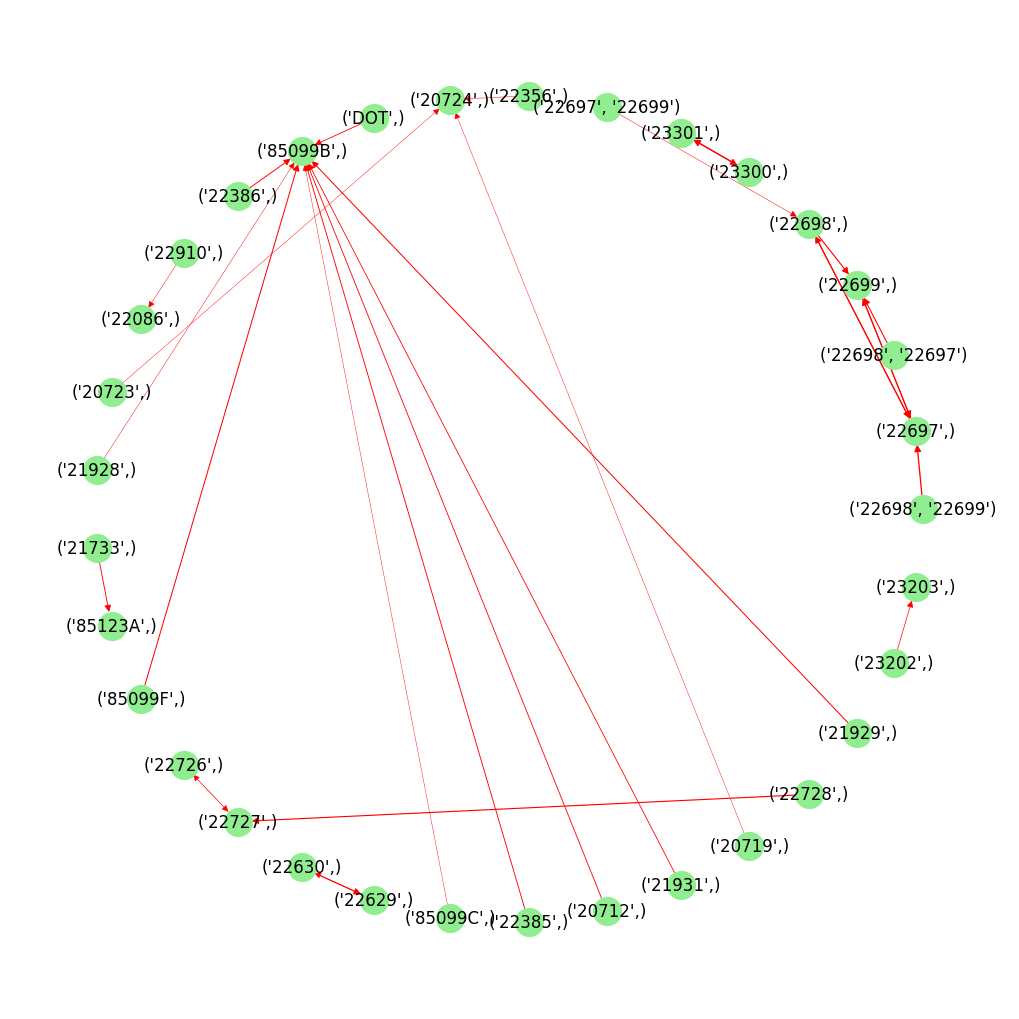

```python
import networkx as nx

G_rules = nx.from_pandas_edgelist(
    rules,
    source="antecedent",
    target="consequent",
    edge_attr="lift",
    create_using=nx.MultiDiGraph(),
    )

plt.figure(figsize=(10, 10))
width = rules["lift"].values / 20
nx.draw_circular(
    G_rules,
    node_color="lightgreen",
    edge_color="red",
    width=width,
    with_labels=True,
    node_size=400,
)
plt.show()
```

```python
from graphframes import *

rules_spark = model.associationRules.sort("confidence", ascending=[False]).limit(30)
vertices = rules_spark.select("antecedent").union(rules_spark.select("consequent")).distinct()
vertices = vertices.withColumnRenamed("antecedent", "name")
vertices = vertices.withColumn("id", vertices.name)
edges = rules_spark.select("antecedent", "consequent")
edges = edges.withColumnRenamed("antecedent", "src")
edges = edges.withColumnRenamed("consequent", "dst")

g = GraphFrame(vertices, edges)
g.inDegrees.sort("inDegree", ascending = [False]).show()
```

```
+--------+--------+
|      id|inDegree|
+--------+--------+
|[85099B]|       9|
| [22697]|       3|
| [22699]|       3|
| [20724]|       3|
| [22698]|       2|
| [22727]|       2|
| [23301]|       1|
| [22086]|       1|
|[85123A]|       1|
| [22629]|       1|
| [22726]|       1|
| [23300]|       1|
| [22630]|       1|
| [23203]|       1|
+--------+--------+
```

#### Time Series Forecasting

In order to delve deeper into time series forecasting, we integrated the Prophet library with PySpark to generate sales forecasts. Leveraging Spark SQL, we orchestrated the creation of a Pandas DataFrame specifically designed for time series analysis. This approach allows us to harness the forecasting capabilities of Prophet while benefiting from the distributed processing capabilities of PySpark, enabling accurate predictions and insights into future sales trends.

```python
ts = spark.sql("""
    Select
        Invoice_Date as ds,
        sum(Quantity * UnitPrice) as y
    From Retail_Data
    group by Invoice_date
    Order by 1
""")

ts_pd = ts.toPandas()
ts_pd
```

|  | ds | y |
| --- | --- | --- |
| 0 | 2010-12-01 | 58635.559980 |
| 1 | 2010-12-02 | 46207.279722 |
| 2 | 2010-12-03 | 45620.460071 |
| 3 | 2010-12-05 | 31383.949772 |
| 4 | 2010-12-06 | 53860.179783 |
| ... | ... | ... |
| 300 | 2011-12-05 | 57751.318813 |
| 301 | 2011-12-06 | 54228.369881 |
| 302 | 2011-12-07 | 75076.219795 |
| 303 | 2011-12-08 | 81417.780183 |
| 304 | 2011-12-09 | 32131.529947 |

305 rows × 2 columns

Using Prophet library to create the model.

```python
from prophet import Prophet
import logging

logging.getLogger('py4j').setLevel(logging.ERROR)

model = Prophet(
  interval_width=0.95,
  growth='linear',
  daily_seasonality=False,
  weekly_seasonality=True,
  yearly_seasonality=True,
  seasonality_mode='multiplicative'
  )

# fit the model to historical data
model.fit(ts_pd)
```

```
14:08:34 - cmdstanpy - INFO - Chain [1] start processing
14:08:34 - cmdstanpy - INFO - Chain [1] done processing
```

```
<prophet.forecaster.Prophet at 0x7f9c082f4790>
```

```python
future_ts_pd = model.make_future_dataframe(
  periods=90,
  freq='d',
  include_history=True
  )

# predict over the dataset
forecast_ts_pd = model.predict(future_ts_pd)

forecast_ts_pd.head(5)
```

|  | ds | trend | yhat_lower | yhat_upper | trend_lower | trend_upper | multiplicative_terms | multiplicative_terms_lower | multiplicative_terms_upper | weekly | weekly_lower | weekly_upper | yearly | yearly_lower | yearly_upper | additive_terms | additive_terms_lower | additive_terms_upper | yhat |
| --- | --- | --- | --- | --- | --- | --- | --- | --- | --- | --- | --- | --- | --- | --- | --- | --- | --- | --- | --- |
| 0 | 2010-12-01 | 28895.960406 | 27690.043849 | 71923.691837 | 28895.960406 | 28895.960406 | 0.721257 | 0.721257 | 0.721257 | 0.023465 | 0.023465 | 0.023465 | 0.697791 | 0.697791 | 0.697791 | 0.0 | 0.0 | 0.0 | 49737.361565 |
| 1 | 2010-12-02 | 28907.132306 | 34546.830544 | 78047.844546 | 28907.132306 | 28907.132306 | 0.936237 | 0.936237 | 0.936237 | 0.253834 | 0.253834 | 0.253834 | 0.682403 | 0.682403 | 0.682403 | 0.0 | 0.0 | 0.0 | 55971.072630 |
| 2 | 2010-12-03 | 28918.304206 | 24635.184090 | 66805.255840 | 28918.304206 | 28918.304206 | 0.600408 | 0.600408 | 0.600408 | -0.063737 | -0.063737 | -0.063737 | 0.664145 | 0.664145 | 0.664145 | 0.0 | 0.0 | 0.0 | 46281.080773 |
| 3 | 2010-12-05 | 28940.648007 | 11511.327570 | 53207.449754 | 28940.648007 | 28940.648007 | 0.097057 | 0.097057 | 0.097057 | -0.520889 | -0.520889 | -0.520889 | 0.617946 | 0.617946 | 0.617946 | 0.0 | 0.0 | 0.0 | 31749.529745 |
| 4 | 2010-12-06 | 28951.819907 | 25461.494643 | 69027.584198 | 28951.819907 | 28951.819907 | 0.632847 | 0.632847 | 0.632847 | 0.043248 | 0.043248 | 0.043248 | 0.589600 | 0.589600 | 0.589600 | 0.0 | 0.0 | 0.0 | 47273.896591 |

Visualize the trend and seasonality

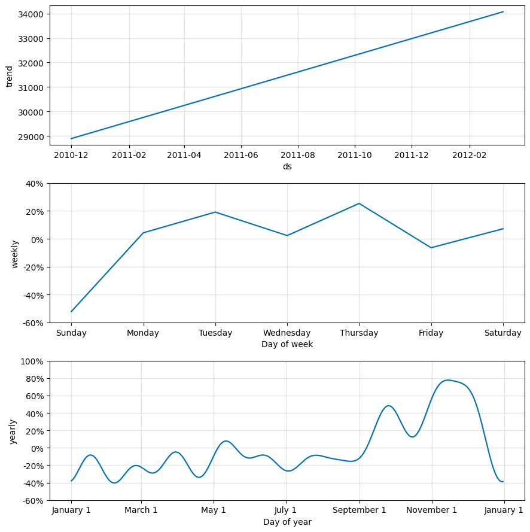

```python
trends_fig = model.plot_components(forecast_ts_pd)
trends_fig.show()
```

Visualize the prediction

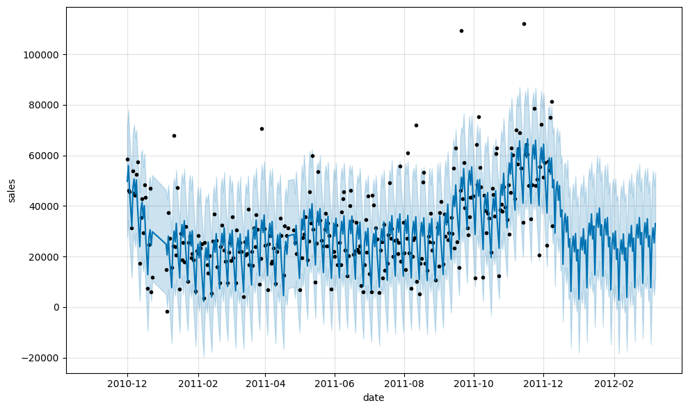

```python
predict_fig = model.plot( forecast_ts_pd, xlabel='date', ylabel='sales')

# adjust figure to display dates from last year + the 90 day forecast
xlim = predict_fig.axes[0].get_xlim()
new_xlim = ( xlim[1]-(180.0+360.0), xlim[1])
predict_fig.axes[0].set_xlim(new_xlim)

predict_fig.show()
```

We calculate the accuracy of the model using MAE, MSE and RMSE

```python
from sklearn.metrics import mean_squared_error, mean_absolute_error
from math import sqrt
from datetime import date

# get historical actuals & predictions for comparison
actuals_pd = ts_pd[ ts_pd['ds'] < date(2018, 1, 1) ]['y']
predicted_pd = forecast_ts_pd[ forecast_ts_pd['ds'] < pd.to_datetime('2011-12-10') ]['yhat']

# calculate evaluation metrics
mae = mean_absolute_error(actuals_pd, predicted_pd)
mse = mean_squared_error(actuals_pd, predicted_pd)
rmse = sqrt(mse)

# print metrics to the screen
print( '\n'.join(['MAE: {0}', 'MSE: {1}', 'RMSE: {2}']).format(mae, mse, rmse) )
```

```
MAE: 7806.473712711784
MSE: 119796215.87508583
RMSE: 10945.145767649046
```

### Conclusion

We can use Pyspark, Prophet and some commond library (pandas, numpy, matplotlib, ..) to analyze the retail online dataset and get the insight from the dataset.

```python
spark.stop()
```